# Week 4: Clustering

Ane Kleiven

2024-09-26

### Answers to questions **Question 1: What is the difference between using Euclidean distance and correlation in clustering analysis, and how does scaling affect these differences?** Euclidian distance gives you the distance between two elements. For example, the distance between two genes. With Euclidian distance you will look at the gene expression in different dimensions (samples). The bigger the distance, the more dissimilar the genes are. Euclidian distance is a dissimilarity measurement. Correlation is measuring how the expression of two genes changes over time, not the expression itself. For example: plot gene 1 against gene 2 and see how close the sample values are (points close to the line). In correlation you want the number to be as high as possible, up to 1. This is a similarity measurement. The difference between these methods in clustering analysis: The Euclidian distance consider how a gene changes expression across the samples, but it is dependent on the expression level. Example: Two genes that both have their highest expression in the floem, might not be in the same cluster if one gene has very high expression in the floem and the other have lower expression in the floem. In Euclidian distance the data must be scaled. The data is scaled because we are interested in how the genes change, and not whether they are high or low. In the R-data “Week 4, heatmat”, the heatmap with scaled data and Euclidian distance, have clear clusters and looks correct according to the article. Correlation only looks at the profile of gene expression, it doesn’t care about expression level. In the heat map based on correlation, we focus on where each gene has its highest expression. The heat map using correlation looks the same both scaled and unscaled, because the data is independent of measurement units. When using unscaled data in correlation, you need to scale the colors. The heat map of scaled data with Euclidian distance and the heat map of correlation looks the same. That is because scaling the Euclidian distance removes the expression level. **Question 2: Case study: You are given a transcriptomics data set with measurement of gene expression (VST) in a number of individuals (genes x samples/individuals table). You are also given the results of several Chip-seq experiments that associate a number of transcription factors (TFs) with genes (TFs x genes table). You suspect that the individuals suffer from several different diseases possibly caused by mis-regulation of some of the same genes. You assume that the different diseases are caused by up-regulation of genes through up-regulation of TFs or mutations that recruit TFs to new promoters. You would like to find the subset of genes and TFs characteristic to each disease. How would you analyze the data? Explain how the chosen method works and how it would give the desired result.** To look at both the gene expression and the transcription factors with genes and find the subset of genes and TF’s characteristic to each disease I would use the Ping-Pong algorithm method. The ping-pong-method does bi-clustering on the two different data sets and can be used to integrate two different data sets into one co-module. The Ping-Pong algorithm is based on the ISA = Iterative Signature Algorithm. In the Ping-Pong algorithm you need to have one common dimension. In this example the common dimension are the genes. The method works like this: You have one expression table with genes and samples (cell lines) and one TF-table with transcription factors (TFs) and genes. You find one subset of genes, one subset of samples and one subset of transcription factors. Start with a random gene signature (a predefined set of genes, G) and find the samples where these genes are up-regulated. This is called the cell line signature. Find a transcription factor signature of TFs or mutations that causes a response in the cell line signature. Refine the cell line signature using the data from the transcription factor data. Refine the gene signature using the expression data This algorithm is iterative and is repeated until you have a fitted model with upregulated genes that are affected by different transcription factors.

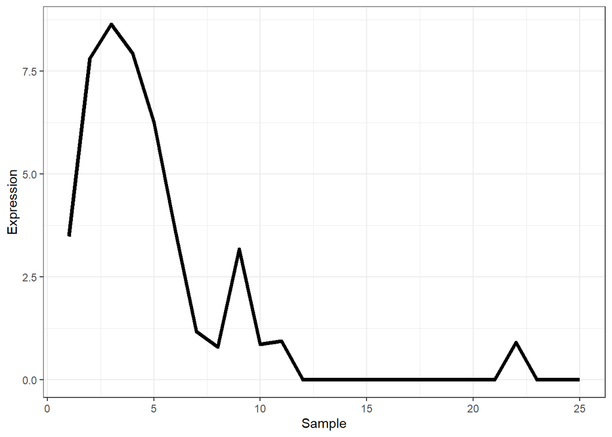

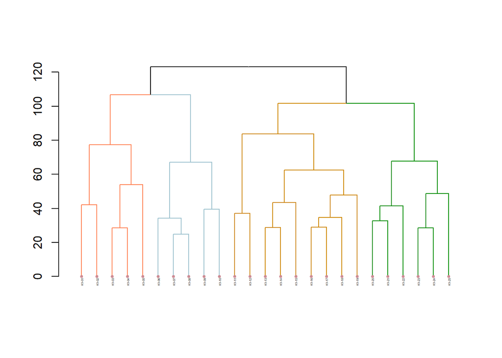

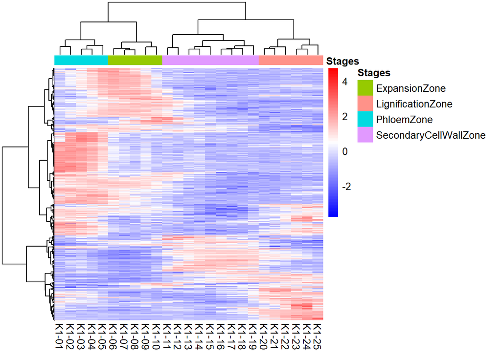

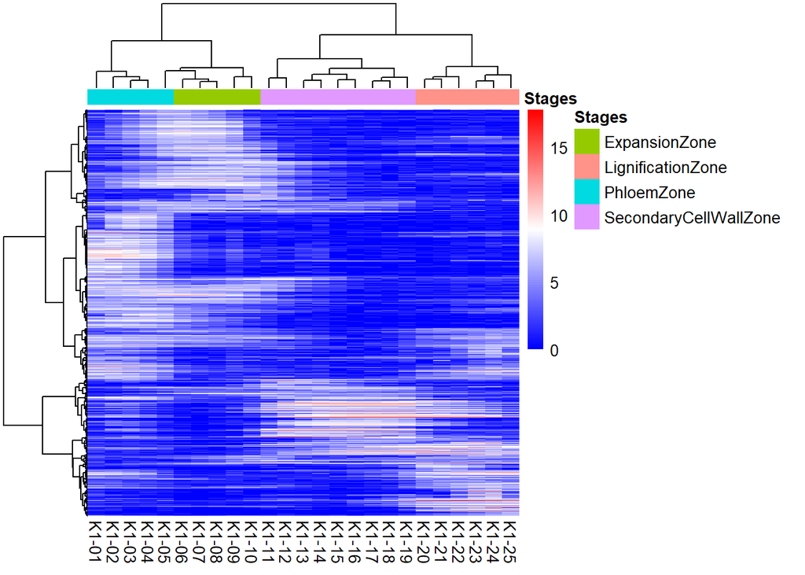

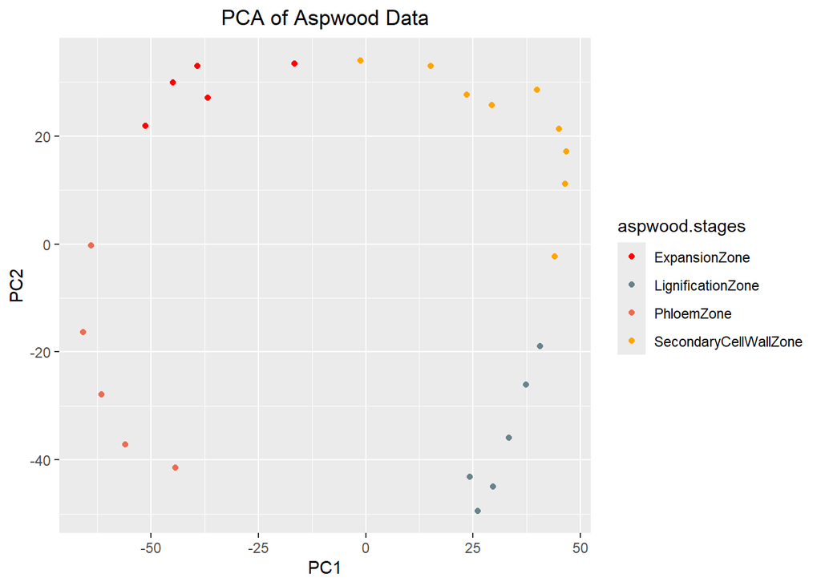

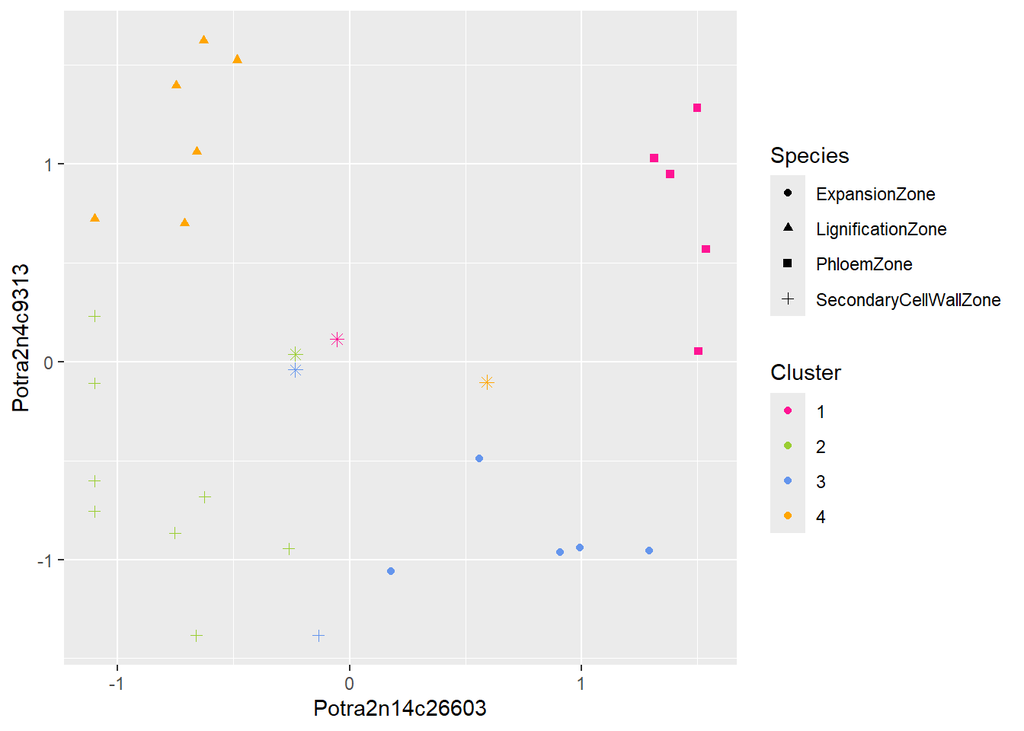